# 22_area_parallelogram

## 22_area_parallelogram

#### Question

1. The figure below shows 7 polygons on a $10\times10$ grid. The grid is composed of 100 squares, each with an area of 1. Each polygon’s area is labelled with an uppercase letter from $A$ to $G$.

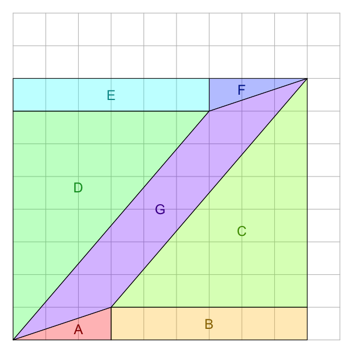

   Find the areas of the triangles, rectangles, and parallelogram.
   - $A=$
   - $B=$
   - $C=$
   - $D=$
   - $E=$
   - $F=$
   - $G=$

#### Question

2. The figure below shows 7 polygons on a $10\times10$ grid. The grid is composed of 100 squares, each with an area of 1. Each polygon’s area is labelled with an uppercase letter from $A$ to $G$.

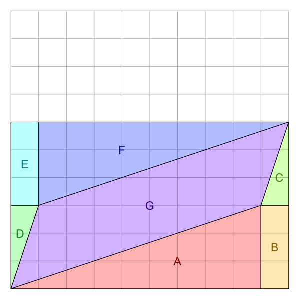

   Find the areas of the triangles, rectangles, and parallelogram.
   - $A=$
   - $B=$
   - $C=$
   - $D=$
   - $E=$
   - $F=$
   - $G=$

#### Question

3. The figure below shows 7 polygons on a $10\times10$ grid. The grid is composed of 100 squares, each with an area of 1. Each polygon’s area is labelled with an uppercase letter from $A$ to $G$.

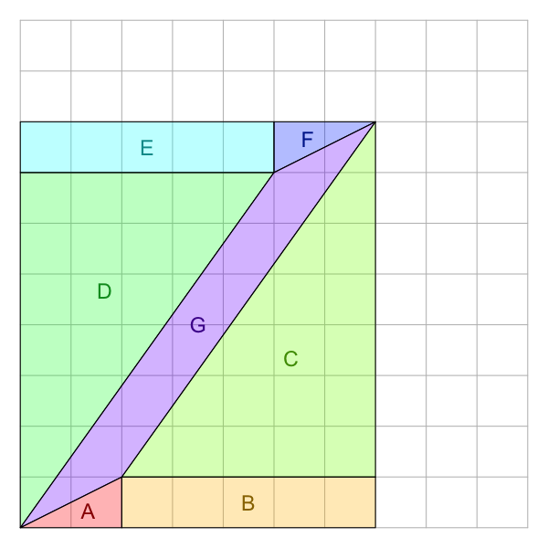

   Find the areas of the triangles, rectangles, and parallelogram.
   - $A=$
   - $B=$
   - $C=$
   - $D=$
   - $E=$
   - $F=$
   - $G=$

#### Question

4. The figure below shows 7 polygons on a $10\times10$ grid. The grid is composed of 100 squares, each with an area of 1. Each polygon’s area is labelled with an uppercase letter from $A$ to $G$.

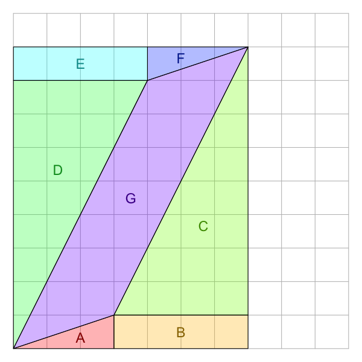

   Find the areas of the triangles, rectangles, and parallelogram.
   - $A=$
   - $B=$
   - $C=$
   - $D=$
   - $E=$
   - $F=$
   - $G=$

#### Question

5. The figure below shows 7 polygons on a $10\times10$ grid. The grid is composed of 100 squares, each with an area of 1. Each polygon’s area is labelled with an uppercase letter from $A$ to $G$.

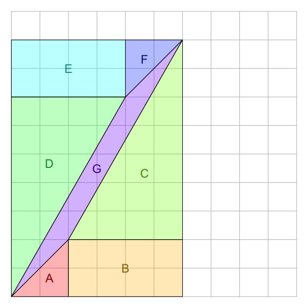

   Find the areas of the triangles, rectangles, and parallelogram.
   - $A=$
   - $B=$
   - $C=$
   - $D=$
   - $E=$
   - $F=$
   - $G=$

#### Question

6. The figure below shows 7 polygons on a $10\times10$ grid. The grid is composed of 100 squares, each with an area of 1. Each polygon’s area is labelled with an uppercase letter from $A$ to $G$.

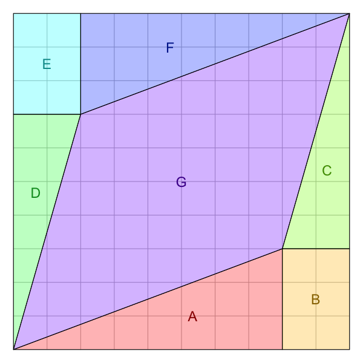

   Find the areas of the triangles, rectangles, and parallelogram.
   - $A=$
   - $B=$
   - $C=$
   - $D=$
   - $E=$
   - $F=$
   - $G=$

#### Question

7. The figure below shows 7 polygons on a $10\times10$ grid. The grid is composed of 100 squares, each with an area of 1. Each polygon’s area is labelled with an uppercase letter from $A$ to $G$.

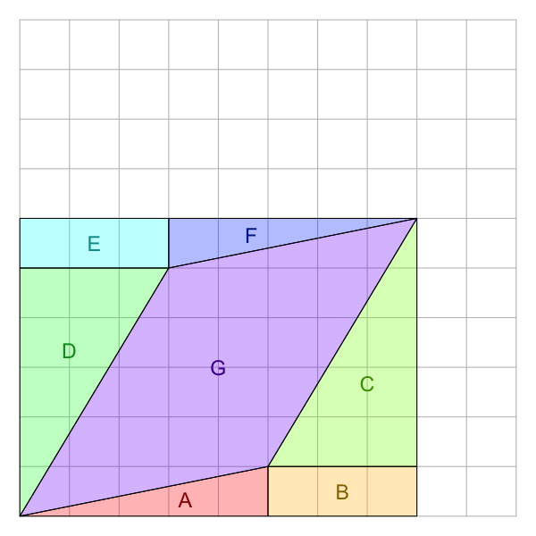

   Find the areas of the triangles, rectangles, and parallelogram.
   - $A=$
   - $B=$
   - $C=$
   - $D=$
   - $E=$
   - $F=$
   - $G=$

#### Question

8. The figure below shows 7 polygons on a $10\times10$ grid. The grid is composed of 100 squares, each with an area of 1. Each polygon’s area is labelled with an uppercase letter from $A$ to $G$.

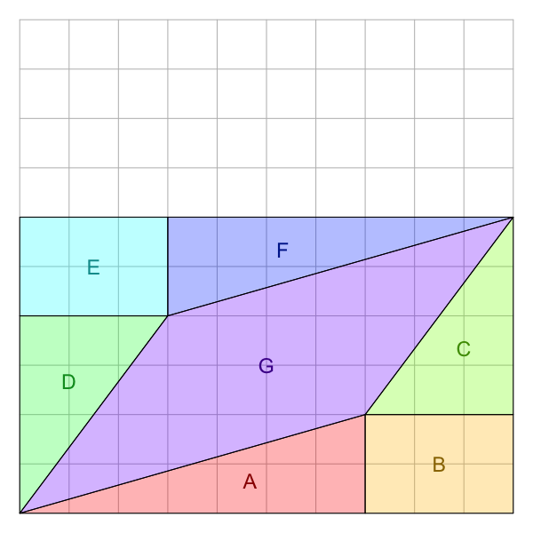

   Find the areas of the triangles, rectangles, and parallelogram.
   - $A=$
   - $B=$
   - $C=$
   - $D=$
   - $E=$
   - $F=$
   - $G=$